# Physical Fractions

Kaelin Sylva

### What is it?

Physical fractionation is a process used to separate soil based on size and density (Gregorich et al, 2006). It assumes that soil physical components and structure will determine its behavior and interactions. Additionally, with soils being complex systems influenced by different forming factors, they can separated using different processes. These processes include separation by soil texture, particle size, aggregates and density. With many permutations of physical fractionation methods in the literature (Figure 1), the research question should dictate what method is chosen.

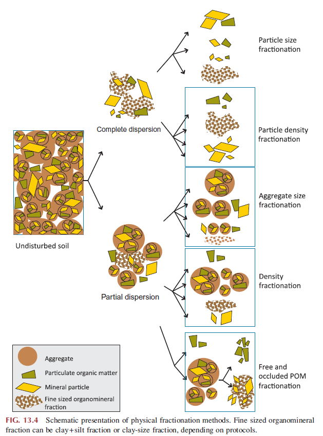

Figure 1. A flow chart diagram that demonstrates the complexity of separation of by physical properties.For more detailed information on the diagram, please refer to chapter 13 in “Soil microbiology, ecology, and biochemistry” (Paul, 2015).

**Helpful Links:**

1. Brady, Niles, and Ray R. Weil. 2008. The Nature and Properties of Soil, 14th edition. Upper Saddle River, NJ: Prentice Hall.
2. Elliott, E.T., Cambardella, C.A. (1991). “Physical separation of soil organic matter”. Agriculture,Ecosystems & Environment 34, 407–419.
3. Gregorich, E. G., Beare, M. H., McKim, U. F., & Skjemstad, J. O. (2006). “Chemical and biological characteristics of physically uncomplexed organic matter”. Soil Science Society of America Journal, 70(3), 975-985.
4. Moni, C., Derrien, D., Hatton, P.J., Zeller, B., & Kleber, M. (2012). “Density fractions versus size separates: does physical fraction isolate functional soil compartments?” Biogeosciences, 9, 5181-5197. DOI: [10.5194/bg-9-5181-2012](https://www.biogeosciences.net/9/5181/2012/bg-9-5181-2012.pdf)
5. Paul, E. (2015). *Soil microbiology, ecology, and biochemistry*. Academic Press.

### How do you separate them?

#### Soil Texture

Soil texture is proportions of different sized particles (sand, silt, and clay). When there is a considerable amount of clay particles present, the particles will clump together creating aggregates. Qualitatively, soil texture can be described as the way soil feels and looks which is influenced by the type and the size of each particle. Sand, silt, and clay (Table 1 and Figure 2) particles are the basis of soil texture and combine into more specific texture classifications. Given a soil’s textural classification, information about the soil’s water holding capacity, productivity, nutrient retention, and carbon-sequestration capacity may be implied.

Table 1. Breakdown of the size classes as provided by the US Department of Agriculture (USDA).

| Mineral Particle | Particle Diameter Size (in millimeters) |
| --- | --- |
| Sand | 2.0 - 0.05 |
| Silt | 0.05 - 0.002 |
| Clay | less than 0.002 |

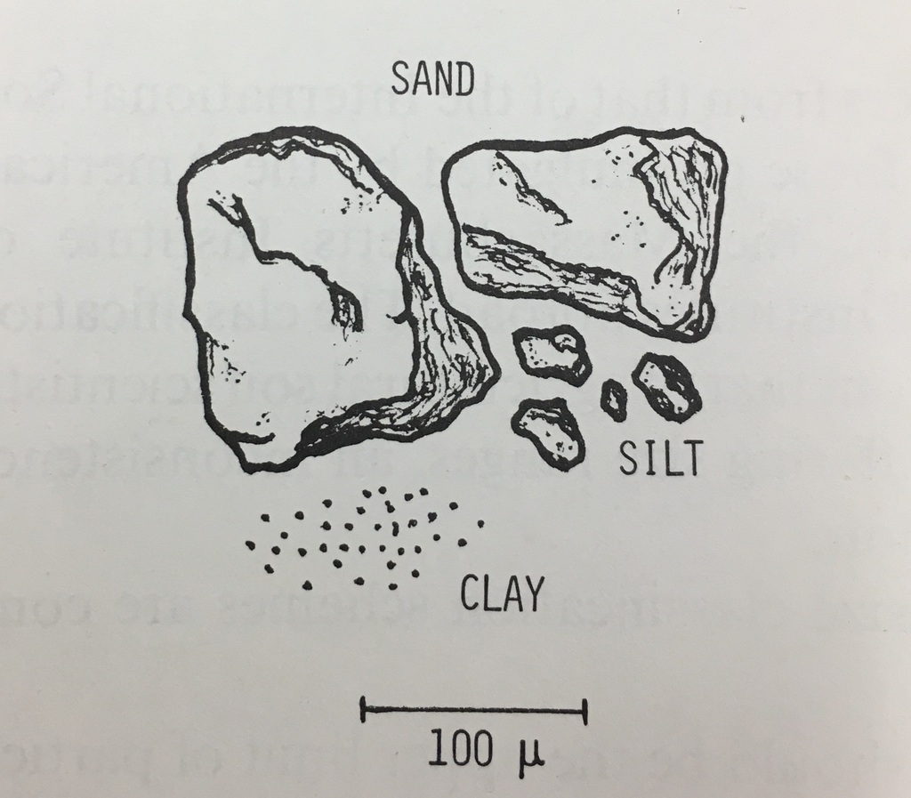

Figure 2. Visual comparison of the size and shapes of each separate. Refer to the text written by Hillel for the original image.

##### Utilizing Soil Texture

The best way to determine the percentages of each size class is through laboratory analysis via a particle size analysis. Coupled with the laboratory analysis, given the percentages of sand, silt, and clay the Soil Textural Triangle (Figure 3) can tell you the classification of the sample. If you don’t have access to a lab, there is a in the field method to determine the texture class is by feel. The USDA has provided a modified guide from Thien on their [website](https://www.nrcs.usda.gov/wps/portal/nrcs/detail/soils/edu/?cid=nrcs142p2_054311) (1979). Soil texture is an important attribute for descriptive purposes, but does not change under land use, management, or experimentation.Therefore, is rarely a quantitative measure used in process-level or mechanistic studies.

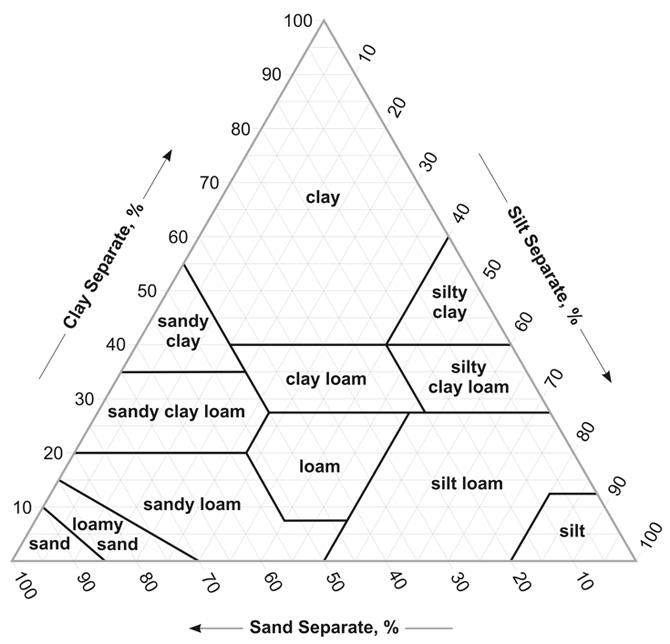

Figure 3. The Soil Texture Triangle provided by the NRCS. If you would like to utilize this tool, please refer to the [link](https://www.nrcs.usda.gov/wps/portal/nrcs/detail/soils/survey/?cid=nrcs142p2_054167).

**Helpful Links**

6. Hillel, D. (2013). *Fundamentals of soil physics*. Academic press.
7. Thien, S. J. (1979). A flow diagram for teaching texture-by-feel analysis. Journal of Agronomic Education, 8(2).

#### Particle Size Fractionation

Soils are composed of different sized particles in which determine different properties regarding the soil. Dispersion, or the process of separating soil into individual particles, by wetting allows for one to determine the stability of the soil structure. This factor of soil is heavily influenced by soil texture, clay content, soil organic matter, salinity, and exchangeable cations. As an example, if a soil is dispersed upon wetting, it indicates that the structure is unstable. An unstable structure usually indicates poor water storage as a result of swelling of the particles restricting movement of water flow. This being said, when utilizing particle size fractionation, there is a need to conduct stronger dispersion treatments in order to break the bonds between elements and the soil. However, if the soil is dispersed too much, it can be abrasive and breakdown particulate organic matter.

As the name implies, this form of physical fractionation separates individual particles by their size. This can be done in different ways such as applying chemical, mechanical, or ultrasonic techniques. In order to sort by the particle sizes, methods such as sieving or sedimentation can be utilized. Furthermore, this type of fractionation, we eliminate any unwanted material and can quantify the different types of particles, aggregates, and other material within the sample.

##### Utilizing Particle Size Fractionation

There is more than one way to determine particle size of soil samples. It is noted that coupled with the soil texture methods, particle size fractions can provides more information regarding the bulk sample. Initially, samples are dried and larger stones and plant biomass will be removed by hand. To dry the sample, it can either be air dried or it can be placed in an oven. Below are some methods that will be conducted after the soil has been processed.

- **Deflocculation**
  - This method is used to separate cementing agents (substances that glue particles together). Separation can either be done by hand or through a mechanized shaker. Dispersing agents such as sodium metaphosphate are used so that you can prevent mistaking aggregates for silt or sand particles.
- **Sedimentation**
  - To identify finer particles, samples will be subjected to being suspended in a solution. The mixture will be centrifuged separating larger particles from the smaller ones. Larger particles will fall to the bottom of the container first and the smaller particles will eventually settle.

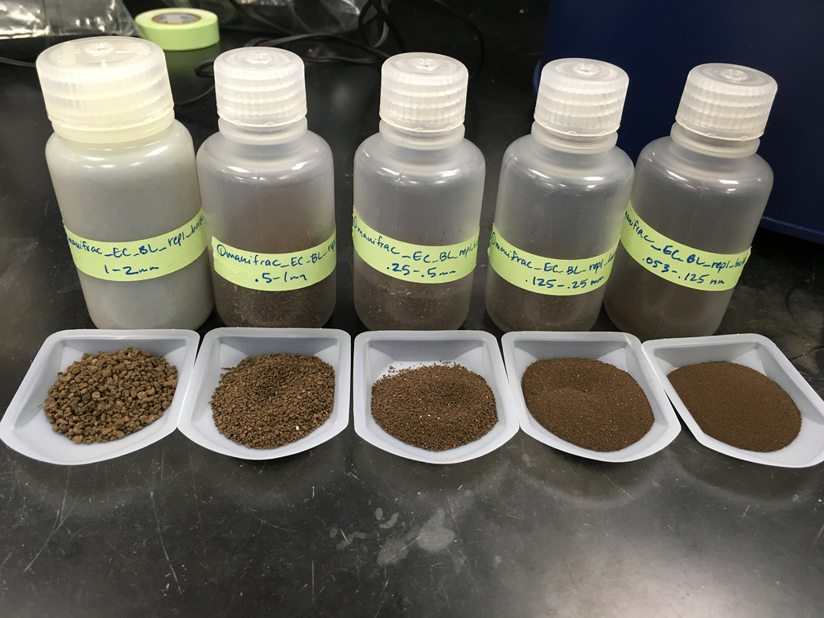

Figure 4. Soil samples that have been sieved at different sizes. The largest sized particles at 1-2 mm and smallest at 0.053-0.125 mm. Photo courtesy of Hannah Hubanks.

**Helpful Links:**

8. Hillel, D. (2013). *Fundamentals of soil physics*. Academic press.
9. Gee, G. W., & Or, D. (2002). “2.4 Particle-size analysis”. Methods of soil analysis. Part, 4(598),255-293.

### Aggregate Size Fractionation

As the name implies, this form of physical fractionation separates individual particles by their size. This process allows for the complete breakdown of macroaggregates (particles greater than 250 μm or micrometers) into microaggregates (particles less than 250 μm). This can be done in different ways such as applying chemical, mechanical, or ultrasonic techniques. Of the listed methods, it is suggested that ultrasonic techniques could be utilized as an alternative to traditional methods. With aggregate fractionation, we eliminate any unwanted material and can quantify the different types of particles, aggregates, and other organic material within the sample.

**Utilizing Aggregate Fractionation**

Similar to particle size fractionation, there are multiple ways to go about this process. It is noted that some equipment may be too abrasive for particles, while others may not properly disperse them (Whitbread, 1995).

- **Dry Sieving**
  - After the removal of larger particles, the sample will be pushed through sieves with different sized screens. Some screen sizes include: <2, 2-5, 5-20, or 20-50 μm (micrometers). Additionally, they can either go through a dry or wet sieving process. Separation can be done by hand or with equipment designed to shake samples. This method is ideal for bulk samples and can break them down into smaller sizes.
- **Water-stable Aggregation**
  - Samples need to be well mixed to be sieved with a 2 millimeter sieve and then microsieves (250 micron and 53 micron). Once completed, it will be dampened then soaked in water. Dry the soil via baking then disrupt it in 5% solution of sodium hexametaphosphate coupled with an additional rise, finally dried. Simple calculations should be used to find the total percentages of water stable aggregates, water stable aggregates larger than 250 microns, and water stable aggregates between 53 and 250 microns.

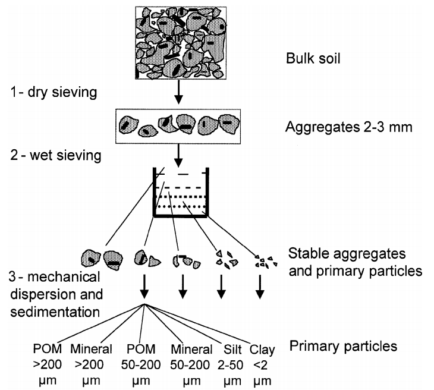

Figure 5. Example of one fractionation process. For more information, please refer to this [link.](https://www.researchgate.net/profile/Claire_Chenu/publication/229915465_Dynamics_of_soil_organic_matter_associated_with_particle-size_fractions_of_water-stable_aggregates/links/56c8d9da08ae110637078f3c.pdf)

**Helpful Links:**

10. Denef, K., Six, J., Bossuyt, H., Frey, S. D., Elliott, E. T., Merckx, R., & Paustian, K. (2001). “Influence of dry–wet cycles on the interrelationship between aggregate, particulate organic matter, and microbial community dynamics”. Soil Biology and Biochemistry,33(12-13), 1599-1611.
11. Kemper, W. D., and R. C. Rosenau. Aggregate stability and size distribution. (1986): 425-442.
12. Puget, P., Chenu, C., & Balesdent, J. (2000). “Dynamics of soil organic matter associated with particle‐size fractions of water‐stable aggregates”. European Journal of Soil Science, 51(4), 595-605.
13. Whitbread, A. M. (1995). “Soil organic matter: its fractionation and role in soil structure”. Soil organic matter management for sustainable agriculture, 124-130.

#### Particle or Aggregate Density Fractionation

This method assumes that the soil can be separated into different parts and relies on separation based on densities. According Swanston et al., densities are referred to as simply the “heavy fraction” or the “light fraction” (2002). Through this method, we can better understand organic matter turnover and stabilization, which is associated with organic mineral interaction. With “heavy fractions”, there are more minerals present thus there will be a low carbon to nitrogen ratio, which would indicate a slow turnover rate. While “light fractions”, there are less minerals and will be a higher carbon to nitrogen ratio, which would indicate faster turnover rates (Whitbread, 1995).

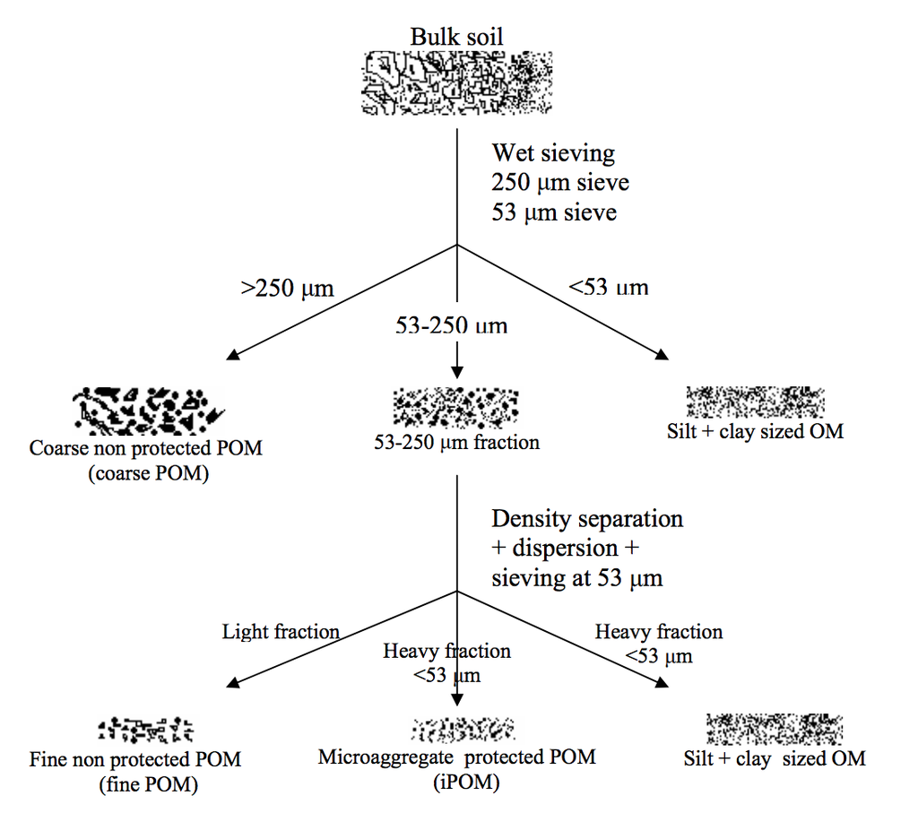

Figure 6. Flow chart of a multi-part fractionation. This particular process includes breakdown of macroaggregates via wet sieving coupled with a density fraction to further separate the sample. Please refer to the original paper for more information.

##### Utilizing Density Fractionation

In order to perform a density fractionation, inorganic or organic liquids may be used. This includes bromoform-ethanol mixtures, tetrachlromethane, sodium iodide, and sodium polytungstate (SPT). Most commonly, labs will utilize SPT as a result of its ability to isolate two or more fractions. The mixture often is centrifuged in order to facilitate separation, and the result is a fraction that floats on a given density and one that sinks.

**Helpful Links:**

14. Crow, S. E., Swanston, C. W., Lajtha, K., Brooks, J. R., & Keirstead, H. (2007). “Density fractionation of forest soils: methodological questions and interpretation of incubation results and turnover time in an ecosystem context”. Biogeochemistry, 85(1), 69-90. DOI: [0.1007/s10533-007-9100-8](https://www.nrs.fs.fed.us/pubs/jrnl/2007/nrs_2007_crow_001.pdf)
15. Sollins, P., Kramer, M. G., Swanston, C., Lajtha, K., Filley, T., Aufdenkampe, A. K., & Bowden, R. D. (2009). “Sequential density fractionation across soils of contrasting mineralogy: evidence for both microbial-and mineral-controlled soil organic matter stabilization”. Biogeochemistry, 96(1-3), 209-231.DOI: [10.1007/s10533-009-9359-z](https://websites.pmc.ucsc.edu/~mkramer/publications/Kramer_2009_Biogeochem.pdf)
16. Swanston, C. W., B. A., Homann, P. S., Ganio, L., & Sollins, P. (2002). “Carbon synamics during a long-term incubation of separate and recombined density fractions from seven forest soils”. Soil Biology and Biochemistry, 34 (8), 1121-1130.

### Applications of Physical Fractions

**Particle Size Fractionation**

A word to the wise - there is no universal method to obtain information on soils as they are complex and have different factors to influence their development. One example of this are the clays within Hawai’i. Within a study conducted by Silva et al., the researchers explored how to improve particle size analysis techniques on Hawaiian clays. To do so they utilized dispersion and ultrasonication. From their study, they found that increasing the dispersant concentration resulted in no change little to no change in clay estimates. However, when the ultrasonic energy increased, there was a noticeable change. With this being said, there is no clear cut method to obtain the information on soil characteristics.

- Silva, J. H., Deenik, J. L., Yost, R. S., Bruland, G. L., & Crow, S. E. (2015). “Improving clay content measurement in oxidic and volcanic ash soils of Hawaii by increasing dispersant concentration and ultrasonic energy levels”. Geoderma, 237, 211-223. DOI: 10.1016/J.GEODERMA.2014.09.008

**Aggregate Fractionation**

Aggregates are soil particles that clump together and the spaces in between hold can air, water, microbes, or organic matter. With this being said, Denef et al. conducted a study to see what dry and wet cycles have on the relationship between aggregate turnover, organic matter, and microbes. Samples were separated by wet sieving starting at >2000 μm, 250-2000 μm, 53-250 μm, and finally <53 μm. In addition to this separation, Denef et al. used a size density fractionation to get light fractions and intra-aggregate organic matter. From these analysis, they concluded that coarse intra-aggregate organic matter into fine intra-aggregate organic matter will occur more often when there is no dry-wet cycle, thus there will be a slower macroaggregate turnover rate.

- Denef, K., Six, J., Bossuyt, H., Frey, S. D., Elliott, E. T., Merckx, R., & Paustian, K. (2001). Influence of dry–wet cycles on the interrelationship between aggregate, particulate organic matter, and microbial community dynamics. Soil Biology and Biochemistry, 33(12-13), 1599-1611.

**Density Fractionation**

To demonstrate the process of density fractionation, the paper by Crow et al. was able to discuss the basis of this method by comparing two soil samples collected in forest settings. Additionally, there wanted to quantify the amount of nitrogen and carbon were lost during separation. Within their experiment, samples were separated by flotation in a SPT solution and once separated was incubated for a year. From the experiment they found that be roughly 17%-26% of nitrogen and carbon were during the separation process.

- Crow, S. E., Swanston, C. W., Lajtha, K., Brooks, J. R., & Keirstead, H. (2007). “Density fractionation of forest soils: methodological questions and interpretation of incubation results and turnover time in an ecosystem context”. Biogeochemistry, 85(1), 69-90. DOI: [0.1007/s10533-007-9100-8](https://www.nrs.fs.fed.us/pubs/jrnl/2007/nrs_2007_crow_001.pdf)